# Contagious Yawning in Dogs: Re-analysis (Part 2)

Scott Claessens and Patrick Neilands

2020-01-09

The purpose of this document is to re-analyse the data from six studies of contagious yawning in dogs. These studies are:

- [Joly-Mascheroni et al. (2008)](https://royalsocietypublishing.org/doi/abs/10.1098/rsbl.2008.0333)
- [O’Hara & Reeve (2011)](https://www.sciencedirect.com/science/article/pii/S0003347210004483)
- [Silva et al. (2012)](https://link.springer.com/article/10.1007/s10071-012-0473-2)
- [Madsen & Persson (2013)](https://link.springer.com/article/10.1007/s10071-012-0568-9)
- [Romero et al. (2013)](https://journals.plos.org/plosone/article?id=10.1371/journal.pone.0071365)
- [Buttner & Strasser (2014)](https://link.springer.com/article/10.1007/s10071-013-0641-z)

We would like to thank the authors of these studies for kindly sharing their original data with us.

# 0. Setup

Load the data.

```r
d <-
  read.csv('data/yawnReanalysis.csv') %>%
  as_tibble() %>%
  # create dummy variables for re-analysis
  mutate(condition    = ifelse(condition == "Control", 0, 1),
         familiar     = ifelse(familiar  == "Unfamiliar", 0, 1),
         type         = ifelse(type == "Shelter", 0, 1),
         presentation = ifelse(presentation == "A", 0, 1),
         live         = ifelse(live == "Recording", 0, 1),
         demonstrator = ifelse(demonstrator == "Human", 0, 1),
         male         = ifelse(gender == 'F', 0, 1))

d
```

| ID | study | numberYawns | age | gender | trial | condition | presentation | type | demonstrator | familiar | live | secs | male |
| --- | --- | --- | --- | --- | --- | --- | --- | --- | --- | --- | --- | --- | --- |
| P1 | JM et al | 1 | 5.0000000 | M | 2 | 1 | 1 | 1 | 0 | 0 | 1 | 300 | 1 |
| P2 | JM et al | 5 | 8.0000000 | M | 2 | 1 | 1 | 1 | 0 | 0 | 1 | 300 | 1 |
| P3 | JM et al | 1 | 7.0000000 | M | 1 | 1 | 1 | 1 | 0 | 0 | 1 | 300 | 1 |
| P4 | JM et al | 1 | 4.0000000 | F | 2 | 1 | 1 | 1 | 0 | 0 | 1 | 300 | 0 |
| P5 | JM et al | 2 | 5.0000000 | F | 1 | 1 | 1 | 1 | 0 | 0 | 1 | 300 | 0 |
| P6 | JM et al | 0 | 15.0000000 | M | 2 | 1 | 1 | 1 | 0 | 0 | 1 | 300 | 1 |
| P7 | JM et al | 0 | 7.0000000 | F | 2 | 1 | 1 | 1 | 0 | 0 | 1 | 300 | 0 |
| P8 | JM et al | 1 | 15.0000000 | M | 2 | 1 | 1 | 1 | 0 | 0 | 1 | 300 | 1 |
| P9 | JM et al | 2 | 8.0000000 | M | 1 | 1 | 1 | 1 | 0 | 0 | 1 | 300 | 1 |
| P10 | JM et al | 1 | 5.0000000 | M | 2 | 1 | 1 | 1 | 0 | 0 | 1 | 300 | 1 |

[output cut: 676 more lines]

In Part 1 of this re-analysis, reported in the `yawnReanalysis.rmd` document, we used zero-inflated Poisson distributions to model these data. However, based on the comments of two reviewers, we also ran hurdle Poisson models, and found that they fitted the data better.

Hurdle Poisson models follow a general form similar to zero-inflated Poisson models

$$\begin{eqnarray}
y_i & \sim & \text{HurdlePoisson} (p_i, \lambda_i)\\
\text{logit} (p_i) & = & \alpha_p + \beta_p x_i \\
\text{log} (\lambda_i) & = & \alpha_\lambda + \text{log(offset)} + \beta_\lambda x_i
\end{eqnarray}$$

where $p_i$ is the probability of dogs not yawning (so $1 - p_i$ is the probability of dogs yawning at least once). The Poisson process then models the number of yawns (>0). $\text{log(offset)}$ is the log of the exposure length, and simple algebra means that $\lambda_i$ is now the expected *rate* per exposure length, rather than the count.

As well as fitting the data better than zero-inflated models, this class of model also better fits the designs of the experiments we are re-analysing. From [this paper](https://www.tandfonline.com/doi/full/10.1080/10543400600719384?scroll=top&needAccess=true):

> …if our goal is inference then we would suggest it’s important to choose the model that is most appropriate given the study design. For example, if we were to ask the question âhow many days did you use aspirin in the last 30 days?â to a random group of participants then we would expect to have some participants who never use aspirin (structural zeroes) and some participants who use aspirin but didn’t in the last 30 days (sampling zeroes). This naturally leads to zero-inflated modeling framework. In contrast, if we restrict our sample to participants who use aspirin then it naturally leads to the hurdle modeling framework because we would only have sample zeroes.

We are re-analysing experiments that contain sampling zeroes, not structural zeroes (as defined above), which leads more naturally to a hurdle framework.

# 1. Fit hurdle Poisson models

## 1.1. Intercept-only model

We utlise a Bayesian multilevel modelling approach here, including random effects for individual dogs nested within studies. Throughout, we use the same linear model to predict $\lambda_i$ (the rate of yawning) and $p_i$ (the probability of no yawning). The latter is called `hu` inside the model formula.

We already fitted the intercept only model in the previous document.

```
##  Family: hurdle_poisson
##   Links: mu = log; hu = logit
## Formula: numberYawns ~ 0 + intercept + offset(log(secs)) + (0 + intercept | study/ID)
##          hu ~ 0 + intercept + (0 + intercept | study/ID)
##    Data: d (Number of observations: 686)
## Samples: 4 chains, each with iter = 2000; warmup = 1000; thin = 1;
##          total post-warmup samples = 4000
##
## Group-Level Effects:
## ~study (Number of levels: 6)
##                  Estimate Est.Error l-95% CI u-95% CI Rhat Bulk_ESS Tail_ESS
## sd(intercept)        0.47      0.31     0.08     1.27 1.00     1225     1191
## sd(hu_intercept)     0.88      0.30     0.47     1.62 1.00     2186     2359
##
## ~study:ID (Number of levels: 197)
##                  Estimate Est.Error l-95% CI u-95% CI Rhat Bulk_ESS Tail_ESS
## sd(intercept)        0.54      0.13     0.28     0.79 1.01      804     1093
## sd(hu_intercept)     0.74      0.22     0.24     1.15 1.00      687      568
##
## Population-Level Effects:
##              Estimate Est.Error l-95% CI u-95% CI Rhat Bulk_ESS Tail_ESS
## intercept       -5.83      0.26    -6.33    -5.28 1.00     1512     1756
## hu_intercept     0.83      0.38     0.08     1.60 1.00     1858     2000
##
## Samples were drawn using sampling(NUTS). For each parameter, Eff.Sample
## is a crude measure of effective sample size, and Rhat is the potential
## scale reduction factor on split chains (at convergence, Rhat = 1).
```

What priors did we use?

| prior | class | coef | group | resp | dpar | nlpar | bound |
| --- | --- | --- | --- | --- | --- | --- | --- |
|  | b |  |  |  |  |  |  |
| student_t(3, -2, 10) | b | intercept |  |  |  |  |  |
|  | b |  |  |  | hu |  |  |
| logistic(0, 1) | b | intercept |  |  | hu |  |  |
| student_t(3, 0, 10) | sd |  |  |  |  |  |  |
| student_t(3, 0, 0.5) | sd |  |  |  | hu |  |  |
|  | sd |  | study |  |  |  |  |
|  | sd | intercept | study |  |  |  |  |
|  | sd |  | study |  | hu |  |  |
|  | sd | intercept | study |  | hu |  |  |

[output cut: 4 more lines]

Let’s interpret each parameter in turn. The parameter `hu` is 0.83. This is on the logit scale, so we need to calculate the inverse logit.

```r
post <- posterior_samples(m5.1)

1 - inv_logit_scaled(post$b_hu_intercept) %>% # prob of yawning
  median() %>%
  round(2)
```

```
## [1] 0.31
```

The median probability of yawning is 0.31.

Let’s calculate the average yawning rate once the yawning process gets started.

```r
(exp(post$b_intercept) * 60) %>% # Yawning rate (per min)
  median() %>%
  round(2)
```

```
## [1] 0.17
```

The dogs yawn 0.17 times a minute, on average (very similar to the 0.16 rate from the ZI model).

## 1.2. Condition-only model

Next, we add condition to the model, also as a random effect grouped by individual dogs nested within studies. Again, we fitted this in the previous document.

```
##  Family: hurdle_poisson
##   Links: mu = log; hu = logit
## Formula: numberYawns ~ 0 + intercept + condition + offset(log(secs)) + (0 + intercept + condition | study/ID)
##          hu ~ 0 + intercept + condition + (0 + intercept + condition | study/ID)
##    Data: d (Number of observations: 686)
## Samples: 4 chains, each with iter = 3000; warmup = 1500; thin = 1;
##          total post-warmup samples = 6000
##
## Group-Level Effects:
## ~study (Number of levels: 6)
##                                Estimate Est.Error l-95% CI u-95% CI Rhat Bulk_ESS Tail_ESS
## sd(intercept)                      0.59      0.66     0.02     2.32 1.00     2024     3213
## sd(condition)                      1.04      0.75     0.23     3.02 1.00     1539     2408
## sd(hu_intercept)                   1.17      0.39     0.61     2.12 1.00     3932     4379
## sd(hu_condition)                   1.18      0.49     0.42     2.30 1.00     2502     2394
## cor(intercept,condition)          -0.49      0.51    -0.99     0.79 1.00     1637     2598
## cor(hu_intercept,hu_condition)    -0.36      0.32    -0.84     0.35 1.00     3605     4258
##
## ~study:ID (Number of levels: 197)
##                                Estimate Est.Error l-95% CI u-95% CI Rhat Bulk_ESS Tail_ESS
## sd(intercept)                      0.60      0.19     0.24     1.01 1.00     1864     1597
## sd(condition)                      0.28      0.21     0.01     0.77 1.00     1698     3280
## sd(hu_intercept)                   0.96      0.24     0.48     1.45 1.00     1765     2932
## sd(hu_condition)                   0.28      0.22     0.01     0.83 1.00     1924     2696
## cor(intercept,condition)          -0.42      0.52    -0.99     0.85 1.00     3813     4021
## cor(hu_intercept,hu_condition)     0.06      0.57    -0.94     0.96 1.00     5932     3796
##
## Population-Level Effects:
##              Estimate Est.Error l-95% CI u-95% CI Rhat Bulk_ESS Tail_ESS
## intercept       -6.49      0.41    -7.45    -5.77 1.00     2481     3090
## condition        0.72      0.48    -0.18     1.77 1.00     3386     3390
## hu_intercept     1.45      0.50     0.40     2.41 1.00     3033     3449
## hu_condition    -1.00      0.48    -1.91     0.03 1.00     4285     3816
##
## Samples were drawn using sampling(NUTS). For each parameter, Eff.Sample
## is a crude measure of effective sample size, and Rhat is the potential
## scale reduction factor on split chains (at convergence, Rhat = 1).
```

What priors did we use?

| prior | class | coef | group | resp | dpar | nlpar | bound |
| --- | --- | --- | --- | --- | --- | --- | --- |
|  | b |  |  |  |  |  |  |
| normal(0, 1) | b | condition |  |  |  |  |  |
| student_t(3, -2, 10) | b | intercept |  |  |  |  |  |
|  | b |  |  |  | hu |  |  |
| normal(0, 1) | b | condition |  |  | hu |  |  |
| logistic(0, 1) | b | intercept |  |  | hu |  |  |
| lkj_corr_cholesky(1) | L |  |  |  |  |  |  |
|  | L |  | study |  |  |  |  |
|  | L |  | study:ID |  |  |  |  |
| student_t(3, 0, 10) | sd |  |  |  |  |  |  |

[output cut: 13 more lines]

Get difference in probability of yawning between conditions.

```r
post <- posterior_samples(m5.2)

# yawning probability
cond1 <- 1 - inv_logit_scaled(post$b_hu_intercept)
median(cond1) %>% round(2)
```

```
## [1] 0.19
```

```r
cond2 <- 1 - inv_logit_scaled(post$b_hu_intercept + post$b_hu_condition)
median(cond2) %>% round(2)
```

```
## [1] 0.39
```

```r
diff <- cond2 - cond1

# proportion of prob mass above zero
(sum(diff > 0) / length(diff)) %>% round(2)
```

```
## [1] 0.97
```

Get difference in yawning rate between conditions.

```r
# yawning rates (per minute)
cond1 <- exp(post$b_intercept) * 60
median(cond1) %>% round(2)
```

```
## [1] 0.1
```

```r
cond2 <- exp(post$b_intercept + post$b_condition) * 60
median(cond2) %>% round(2)
```

```
## [1] 0.19
```

```r
diff <- cond2 - cond1

# proportion of prob mass above zero
(sum(diff > 0) / length(diff)) %>% round(2)
```

```
## [1] 0.95
```

Visualise effect of condition.

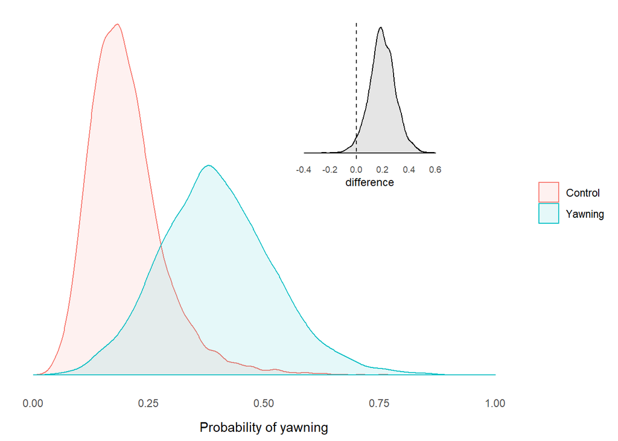

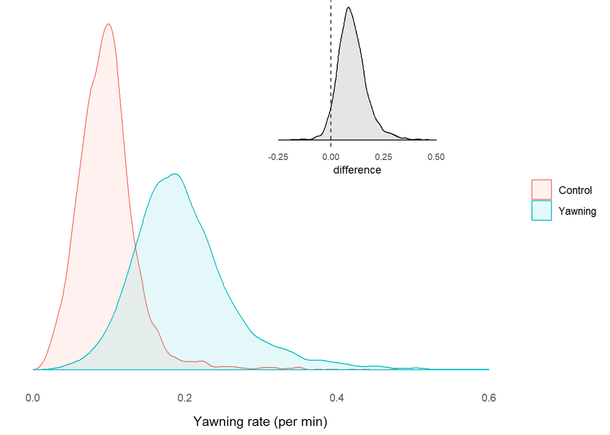

The effect of condition across studies.

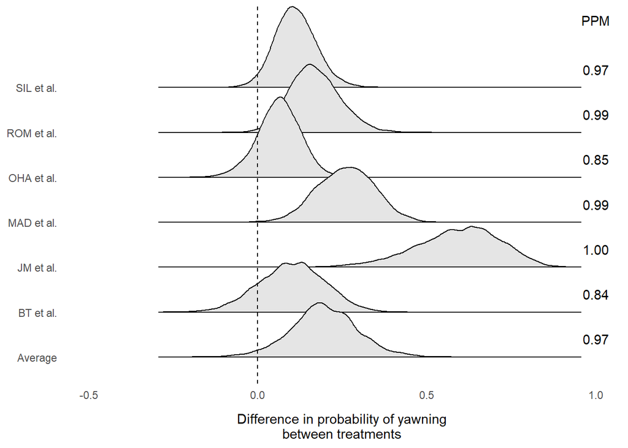

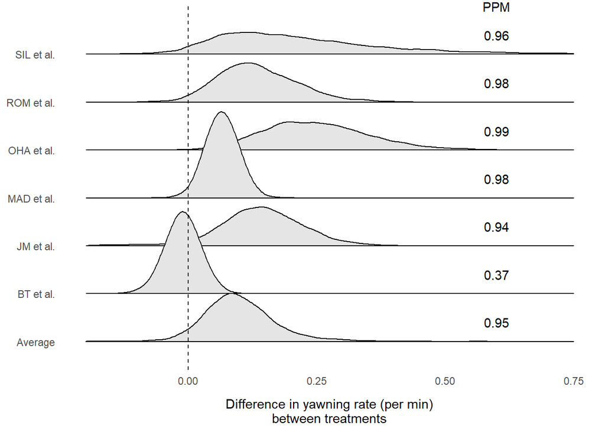

## 1.3. Familiarity-only model

We replace condition with familiarity in the model, again as a random effect grouped by individual dogs nested within studies.

```
##  Family: hurdle_poisson
##   Links: mu = log; hu = logit
## Formula: numberYawns ~ 0 + intercept + familiar + offset(log(secs)) + (0 + intercept | study/ID)
##          hu ~ 0 + intercept + familiar + (0 + intercept | study/ID)
##    Data: d (Number of observations: 686)
## Samples: 4 chains, each with iter = 2000; warmup = 1000; thin = 1;
##          total post-warmup samples = 4000
##
## Group-Level Effects:
## ~study (Number of levels: 6)
##                  Estimate Est.Error l-95% CI u-95% CI Rhat Bulk_ESS Tail_ESS
## sd(intercept)        0.52      0.34     0.11     1.39 1.00     1581     1654
## sd(hu_intercept)     0.88      0.31     0.46     1.62 1.00     1990     2593
##
## ~study:ID (Number of levels: 197)
##                  Estimate Est.Error l-95% CI u-95% CI Rhat Bulk_ESS Tail_ESS
## sd(intercept)        0.52      0.13     0.25     0.78 1.00     1031      857
## sd(hu_intercept)     0.75      0.21     0.32     1.14 1.00      959     1207
##
## Population-Level Effects:
##              Estimate Est.Error l-95% CI u-95% CI Rhat Bulk_ESS Tail_ESS
## intercept       -5.93      0.30    -6.52    -5.32 1.00     1934     2132
## familiar         0.36      0.20    -0.03     0.75 1.00     5637     3296
## hu_intercept     0.77      0.37     0.01     1.49 1.00     1710     1897
## hu_familiar      0.14      0.22    -0.29     0.58 1.00     7370     2790
##
## Samples were drawn using sampling(NUTS). For each parameter, Eff.Sample
## is a crude measure of effective sample size, and Rhat is the potential
## scale reduction factor on split chains (at convergence, Rhat = 1).
```

What priors did we use?

| prior | class | coef | group | resp | dpar | nlpar | bound |
| --- | --- | --- | --- | --- | --- | --- | --- |
|  | b |  |  |  |  |  |  |
| normal(0, 1) | b | familiar |  |  |  |  |  |
| student_t(3, -2, 10) | b | intercept |  |  |  |  |  |
|  | b |  |  |  | hu |  |  |
| normal(0, 1) | b | familiar |  |  | hu |  |  |
| logistic(0, 1) | b | intercept |  |  | hu |  |  |
| student_t(3, 0, 10) | sd |  |  |  |  |  |  |
| student_t(3, 0, 0.5) | sd |  |  |  | hu |  |  |
|  | sd |  | study |  |  |  |  |
|  | sd | intercept | study |  |  |  |  |

[output cut: 6 more lines]

## 1.4. Condition + Familiarity model

We include both condition and familiarity as additive effects.

```
##  Family: hurdle_poisson
##   Links: mu = log; hu = logit
## Formula: numberYawns ~ 0 + intercept + condition + familiar + offset(log(secs)) + (0 + intercept + condition | study/ID)
##          hu ~ 0 + intercept + condition + familiar + (0 + intercept + condition | study/ID)
##    Data: d (Number of observations: 686)
## Samples: 4 chains, each with iter = 3000; warmup = 1500; thin = 1;
##          total post-warmup samples = 6000
##
## Group-Level Effects:
## ~study (Number of levels: 6)
##                                Estimate Est.Error l-95% CI u-95% CI Rhat Bulk_ESS Tail_ESS
## sd(intercept)                      0.71      0.75     0.03     2.74 1.00     1522     2161
## sd(condition)                      1.10      0.85     0.22     3.35 1.00     1189     1596
## sd(hu_intercept)                   1.17      0.38     0.62     2.06 1.00     2408     3583
## sd(hu_condition)                   1.20      0.49     0.45     2.37 1.00     1419     1556
## cor(intercept,condition)          -0.50      0.50    -1.00     0.76 1.00     1142     1980
## cor(hu_intercept,hu_condition)    -0.39      0.32    -0.85     0.34 1.00     1997     2924
##
## ~study:ID (Number of levels: 197)
##                                Estimate Est.Error l-95% CI u-95% CI Rhat Bulk_ESS Tail_ESS
## sd(intercept)                      0.58      0.19     0.22     0.99 1.00     1313      992
## sd(condition)                      0.29      0.21     0.01     0.79 1.00     1231     2333
## sd(hu_intercept)                   0.98      0.24     0.51     1.47 1.00     1606     1956
## sd(hu_condition)                   0.29      0.22     0.01     0.83 1.00     1660     2420
## cor(intercept,condition)          -0.40      0.52    -0.98     0.83 1.00     2520     2910
## cor(hu_intercept,hu_condition)     0.05      0.57    -0.93     0.95 1.00     3661     3938
##
## Population-Level Effects:
##              Estimate Est.Error l-95% CI u-95% CI Rhat Bulk_ESS Tail_ESS
## intercept       -6.59      0.46    -7.62    -5.78 1.00     1765     2158
## condition        0.71      0.50    -0.28     1.77 1.00     2047     2245
## familiar         0.33      0.20    -0.06     0.71 1.00     5808     4077
## hu_intercept     1.41      0.51     0.38     2.39 1.00     1862     2672
## hu_condition    -1.01      0.49    -1.93     0.02 1.00     2361     3401
## hu_familiar      0.12      0.23    -0.34     0.57 1.00     6234     4537
##
## Samples were drawn using sampling(NUTS). For each parameter, Eff.Sample
## is a crude measure of effective sample size, and Rhat is the potential
## scale reduction factor on split chains (at convergence, Rhat = 1).
```

What priors did we use?

| prior | class | coef | group | resp | dpar | nlpar | bound |
| --- | --- | --- | --- | --- | --- | --- | --- |
|  | b |  |  |  |  |  |  |
| normal(0, 1) | b | condition |  |  |  |  |  |
| normal(0, 1) | b | familiar |  |  |  |  |  |
| student_t(3, -2, 10) | b | intercept |  |  |  |  |  |
|  | b |  |  |  | hu |  |  |
| normal(0, 1) | b | condition |  |  | hu |  |  |
| normal(0, 1) | b | familiar |  |  | hu |  |  |
| logistic(0, 1) | b | intercept |  |  | hu |  |  |
| lkj_corr_cholesky(1) | L |  |  |  |  |  |  |
|  | L |  | study |  |  |  |  |

[output cut: 15 more lines]

Get difference in yawning probability between conditions, controlling for familiarity.

```r
post <- posterior_samples(m5.4)

# yawning probability
cond1 <- 1 - inv_logit_scaled(post$b_hu_intercept)
median(cond1) %>% round(2)
```

```
## [1] 0.19
```

```r
cond2 <- 1 - inv_logit_scaled(post$b_hu_intercept + post$b_hu_condition)
median(cond2) %>% round(2)
```

```
## [1] 0.4
```

```r
diff <- cond2 - cond1

# proportion of prob mass above zero
(sum(diff > 0) / length(diff)) %>% round(2)
```

```
## [1] 0.97
```

Get difference in yawning rate between conditions, controlling for familiarity.

```r
# yawning rates (per minute)
cond1 <- exp(post$b_intercept) * 60
median(cond1) %>% round(2)
```

```
## [1] 0.09
```

```r
cond2 <- exp(post$b_intercept + post$b_condition) * 60
median(cond2) %>% round(2)
```

```
## [1] 0.17
```

```r
diff <- cond2 - cond1

# proportion of prob mass above zero
(sum(diff > 0) / length(diff)) %>% round(2)
```

```
## [1] 0.94
```

## 1.5. Condition*Familiarity model

Finally, we allow condition and familiarity to interact with one another.

```
##  Family: hurdle_poisson
##   Links: mu = log; hu = logit
## Formula: numberYawns ~ 0 + intercept + condition * familiar + offset(log(secs)) + (0 + intercept + condition | study/ID)
##          hu ~ 0 + intercept + condition * familiar + (0 + intercept + condition | study/ID)
##    Data: d (Number of observations: 686)
## Samples: 4 chains, each with iter = 3000; warmup = 1500; thin = 1;
##          total post-warmup samples = 6000
##
## Group-Level Effects:
## ~study (Number of levels: 6)
##                                Estimate Est.Error l-95% CI u-95% CI Rhat Bulk_ESS Tail_ESS
## sd(intercept)                      0.80      0.76     0.04     2.74 1.00     1455     1940
## sd(condition)                      1.19      0.87     0.27     3.50 1.00     1378     1809
## sd(hu_intercept)                   1.18      0.41     0.61     2.22 1.00     2715     3357
## sd(hu_condition)                   1.25      0.50     0.52     2.43 1.00     2383     3487
## cor(intercept,condition)          -0.58      0.46    -1.00     0.67 1.00     1370     2295
## cor(hu_intercept,hu_condition)    -0.38      0.31    -0.84     0.33 1.00     2754     3619
##
## ~study:ID (Number of levels: 197)
##                                Estimate Est.Error l-95% CI u-95% CI Rhat Bulk_ESS Tail_ESS
## sd(intercept)                      0.57      0.19     0.22     0.96 1.00     1797     1871
## sd(condition)                      0.28      0.21     0.01     0.78 1.00     1116     2489
## sd(hu_intercept)                   0.99      0.25     0.52     1.47 1.00     1598     1829
## sd(hu_condition)                   0.28      0.22     0.01     0.81 1.00     1421     2650
## cor(intercept,condition)          -0.39      0.52    -0.98     0.85 1.00     2829     3462
## cor(hu_intercept,hu_condition)     0.04      0.57    -0.94     0.96 1.00     4042     3879
##
## Population-Level Effects:
##                       Estimate Est.Error l-95% CI u-95% CI Rhat Bulk_ESS Tail_ESS
## intercept                -6.67      0.48    -7.72    -5.83 1.00     2197     2623
## condition                 0.80      0.55    -0.25     1.91 1.00     2565     3344
## familiar                  0.53      0.39    -0.21     1.32 1.00     3254     3609
## condition:familiar       -0.27      0.43    -1.14     0.56 1.00     3304     3175
## hu_intercept              1.34      0.50     0.30     2.33 1.00     1895     2622
## hu_condition             -0.86      0.50    -1.81     0.20 1.00     2828     3366
## hu_familiar               0.45      0.34    -0.20     1.11 1.00     4571     4656
## hu_condition:familiar    -0.59      0.43    -1.43     0.23 1.00     4295     3962
##
## Samples were drawn using sampling(NUTS). For each parameter, Eff.Sample
## is a crude measure of effective sample size, and Rhat is the potential
## scale reduction factor on split chains (at convergence, Rhat = 1).
```

What priors did we use?

| prior | class | coef | group | resp | dpar | nlpar | bound |
| --- | --- | --- | --- | --- | --- | --- | --- |
|  | b |  |  |  |  |  |  |
| normal(0, 1) | b | condition |  |  |  |  |  |
| normal(0, 1) | b | condition:familiar |  |  |  |  |  |
| normal(0, 1) | b | familiar |  |  |  |  |  |
| student_t(3, -2, 10) | b | intercept |  |  |  |  |  |
|  | b |  |  |  | hu |  |  |
| normal(0, 1) | b | condition |  |  | hu |  |  |
| normal(0, 1) | b | condition:familiar |  |  | hu |  |  |
| normal(0, 1) | b | familiar |  |  | hu |  |  |
| logistic(0, 1) | b | intercept |  |  | hu |  |  |

[output cut: 17 more lines]

Get probability of yawning in each cell of 2x2 design.

```r
post <- posterior_samples(m5.5)

# probability of yawning
cond1unfam <- 1 - inv_logit_scaled(post$b_hu_intercept)
cond2unfam <- 1 - inv_logit_scaled(post$b_hu_intercept + post$b_hu_condition)
cond1fam   <- 1 - inv_logit_scaled(post$b_hu_intercept + post$b_hu_familiar)
cond2fam   <- 1 - inv_logit_scaled(post$b_hu_intercept + post$b_hu_condition +
                    post$b_hu_familiar + post$`b_hu_condition:familiar`)

median(cond1unfam) %>% round(2)
```

```
## [1] 0.21
```

```r
median(cond2unfam) %>% round(2)
```

```
## [1] 0.38
```

```r
median(cond1fam)   %>% round(2)
```

```
## [1] 0.14
```

```r
median(cond2fam)   %>% round(2)
```

```
## [1] 0.42
```

Are there any differences in the probability of yawning? Get proportions of prob mass above zero for each contrast.

```r
diff1 <- cond2fam - cond1unfam
diff2 <- cond2fam - cond2unfam
diff3 <- cond2fam - cond1fam
diff4 <- cond1fam - cond1unfam
diff5 <- cond1fam - cond2unfam
diff6 <- cond2unfam - cond1unfam

(sum(diff1 > 0) / length(diff1)) %>% round(2)
```

```
## [1] 0.96
```

```r
(sum(diff2 > 0) / length(diff2)) %>% round(2)
```

```
## [1] 0.68
```

```r
(sum(diff3 > 0) / length(diff3)) %>% round(2)
```

```
## [1] 0.99
```

```r
(sum(diff4 > 0) / length(diff4)) %>% round(2)
```

```
## [1] 0.09
```

```r
(sum(diff5 > 0) / length(diff5)) %>% round(2)
```

```
## [1] 0.01
```

```r
(sum(diff6 > 0) / length(diff6)) %>% round(2)
```

```
## [1] 0.95
```

Does the effect of condition differ between familiar and unfamiliar demonstrators? Interaction effect.

```r
(sum(diff3 - diff6 > 0) / length(diff3)) %>% round(2)
```

```
## [1] 0.88
```

Get yawning rate in each cell of 2x2 design.

```r
# yawning rates (per minute)
cond1unfam <- exp(post$b_intercept) * 60
cond2unfam <- exp(post$b_intercept + post$b_condition) * 60
cond1fam   <- exp(post$b_intercept + post$b_familiar) * 60
cond2fam   <- exp(post$b_intercept + post$b_condition +
                    post$b_familiar + post$`b_condition:familiar`) * 60

median(cond1unfam) %>% round(2)
```

```
## [1] 0.08
```

```r
median(cond2unfam) %>% round(2)
```

```
## [1] 0.17
```

```r
median(cond1fam)   %>% round(2)
```

```
## [1] 0.13
```

```r
median(cond2fam)   %>% round(2)
```

```
## [1] 0.22
```

Are there any differences in yawning rate? Get proportions of prob mass above zero for each contrast.

```r
diff1 <- cond2fam - cond1unfam
diff2 <- cond2fam - cond2unfam
diff3 <- cond2fam - cond1fam
diff4 <- cond1fam - cond1unfam
diff5 <- cond1fam - cond2unfam
diff6 <- cond2unfam - cond1unfam

(sum(diff1 > 0) / length(diff1)) %>% round(2)
```

```
## [1] 0.97
```

```r
(sum(diff2 > 0) / length(diff2)) %>% round(2)
```

```
## [1] 0.89
```

```r
(sum(diff3 > 0) / length(diff3)) %>% round(2)
```

```
## [1] 0.83
```

```r
(sum(diff4 > 0) / length(diff4)) %>% round(2)
```

```
## [1] 0.91
```

```r
(sum(diff5 > 0) / length(diff5)) %>% round(2)
```

```
## [1] 0.31
```

```r
(sum(diff6 > 0) / length(diff6)) %>% round(2)
```

```
## [1] 0.94
```

Does the effect of condition differ between familiar and unfamiliar demonstrators? Interaction effect.

```r
(sum(diff3 - diff6 > 0) / length(diff3)) %>% round(2)
```

```
## [1] 0.49
```

Visualise.

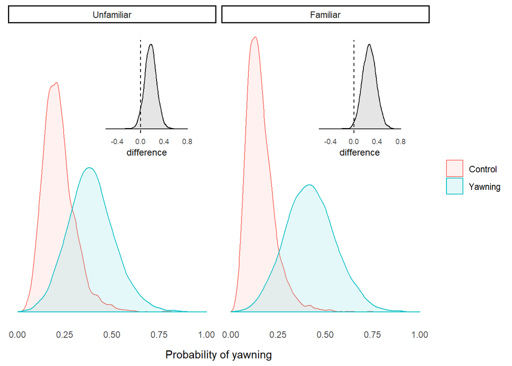

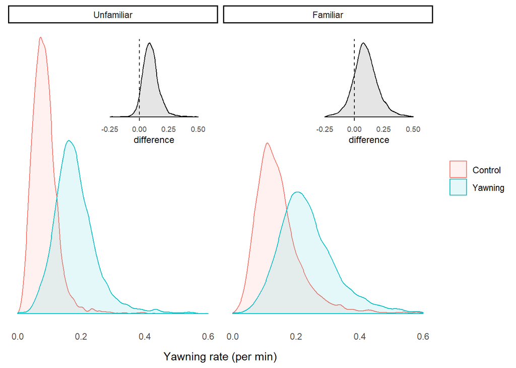

Let’s compare all models so far.

```r
loo_compare(m5.1, m5.2, m5.3, m5.4, m5.5)
```

```
##      elpd_diff se_diff
## m5.5   0.0       0.0
## m5.2  -0.6       2.0
## m5.4  -1.2       1.5
## m5.1 -33.1       7.1
## m5.3 -33.6       6.9
```

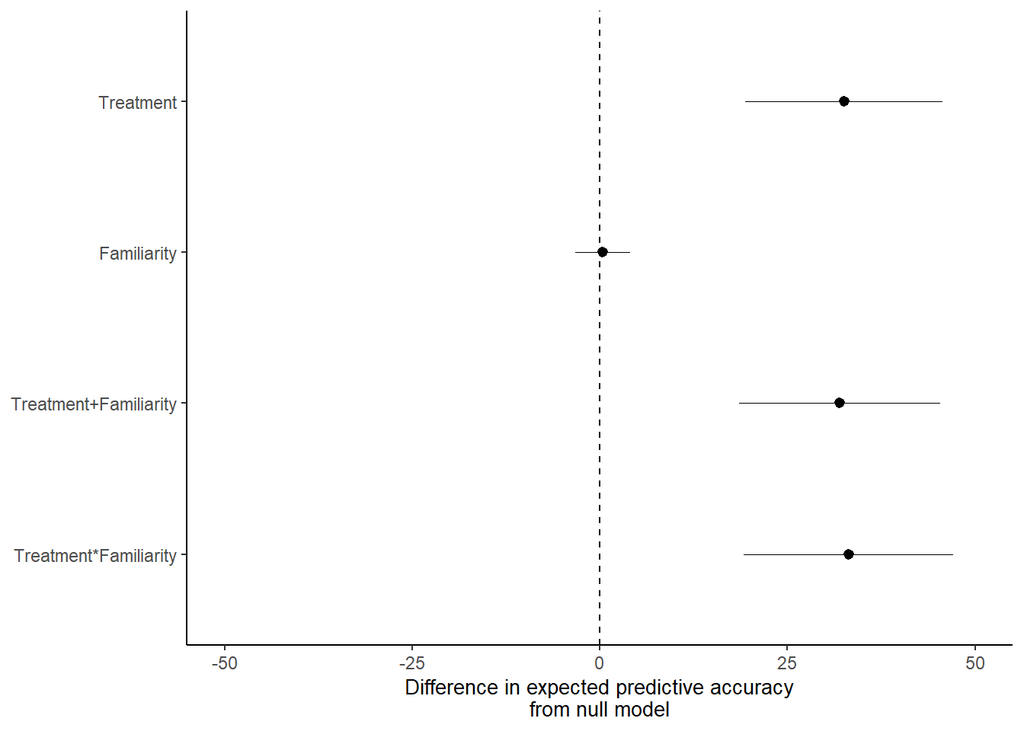

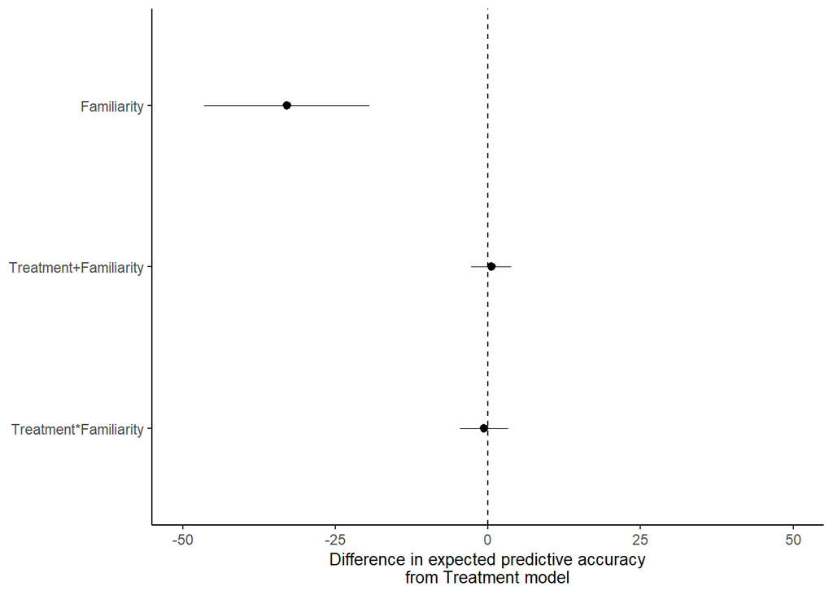

The best models are `m5.2`, `m5.4`, and `m5.5` - all the models that have a condition parameter. None of these models are substantially better than one another. This suggests that condition has an effect, but familiarity doesn’t interact with it.

Going forward, we choose the condition-only model to continue analysing, as the most parsmionious model. Next, we add controls to see if the effect of condition is robust.

## 1.6. Condition + Type model

We include both condition and type (shelter/pet) as additive effects.

```
##  Family: hurdle_poisson
##   Links: mu = log; hu = logit
## Formula: numberYawns ~ 0 + intercept + condition + type + offset(log(secs)) + (0 + intercept + condition | study/ID)
##          hu ~ 0 + intercept + condition + type + (0 + intercept + condition | study/ID)
##    Data: d (Number of observations: 686)
## Samples: 4 chains, each with iter = 2000; warmup = 1000; thin = 1;
##          total post-warmup samples = 4000
##
## Group-Level Effects:
## ~study (Number of levels: 6)
##                                Estimate Est.Error l-95% CI u-95% CI Rhat Bulk_ESS Tail_ESS
## sd(intercept)                      0.59      0.67     0.02     2.49 1.00     1117     1706
## sd(condition)                      1.08      0.77     0.25     3.07 1.00      817      886
## sd(hu_intercept)                   1.19      0.46     0.58     2.28 1.00     1550     2202
## sd(hu_condition)                   1.24      0.52     0.48     2.53 1.00     1436     1628
## cor(intercept,condition)          -0.40      0.55    -0.99     0.84 1.01      766     1510
## cor(hu_intercept,hu_condition)    -0.35      0.33    -0.85     0.37 1.00     1596     2158
##
## ~study:ID (Number of levels: 197)
##                                Estimate Est.Error l-95% CI u-95% CI Rhat Bulk_ESS Tail_ESS
## sd(intercept)                      0.59      0.19     0.23     0.98 1.00     1163      868
## sd(condition)                      0.27      0.20     0.01     0.72 1.00      942     1647
## sd(hu_intercept)                   1.00      0.25     0.50     1.48 1.00      949     1046
## sd(hu_condition)                   0.29      0.22     0.01     0.83 1.00      944     1308
## cor(intercept,condition)          -0.40      0.53    -0.98     0.83 1.00     1735     2311
## cor(hu_intercept,hu_condition)     0.06      0.56    -0.94     0.96 1.00     2643     1991
##
## Population-Level Effects:
##              Estimate Est.Error l-95% CI u-95% CI Rhat Bulk_ESS Tail_ESS
## intercept       -6.36      0.49    -7.48    -5.47 1.00     1088     1666
## condition        0.71      0.50    -0.27     1.71 1.00     1357     1594
## type            -0.18      0.36    -0.90     0.55 1.00     1776     2203
## hu_intercept     1.35      0.64     0.09     2.63 1.00     1207     1629
## hu_condition    -0.98      0.50    -1.92     0.10 1.00     1477     1494
## hu_type          0.13      0.52    -0.90     1.15 1.00     1621     2538
##
## Samples were drawn using sampling(NUTS). For each parameter, Eff.Sample
## is a crude measure of effective sample size, and Rhat is the potential
## scale reduction factor on split chains (at convergence, Rhat = 1).
```

What priors did we use?

| prior | class | coef | group | resp | dpar | nlpar | bound |
| --- | --- | --- | --- | --- | --- | --- | --- |
|  | b |  |  |  |  |  |  |
| normal(0, 1) | b | condition |  |  |  |  |  |
| student_t(3, -2, 10) | b | intercept |  |  |  |  |  |
| normal(0, 1) | b | type |  |  |  |  |  |
|  | b |  |  |  | hu |  |  |
| normal(0, 1) | b | condition |  |  | hu |  |  |
| logistic(0, 1) | b | intercept |  |  | hu |  |  |
| normal(0, 1) | b | type |  |  | hu |  |  |
| lkj_corr_cholesky(1) | L |  |  |  |  |  |  |
|  | L |  | study |  |  |  |  |

[output cut: 15 more lines]

Effect(s) of condition?

```r
post <- posterior_samples(m5.6)
(sum(post$b_hu_condition < 0) / length(post$b_hu_condition)) %>% round(2)
```

```
## [1] 0.97
```

```r
(sum(post$b_condition > 0) / length(post$b_condition)) %>% round(2)
```

```
## [1] 0.93
```

Model comparison.

```r
loo_compare(m5.2, m5.6)
```

```
##      elpd_diff se_diff
## m5.2  0.0       0.0
## m5.6 -0.2       0.7
```

## 1.7. Condition + Presentation model

```
##  Family: hurdle_poisson
##   Links: mu = log; hu = logit
## Formula: numberYawns ~ 0 + intercept + condition + presentation + offset(log(secs)) + (0 + intercept + condition | study/ID)
##          hu ~ 0 + intercept + condition + presentation + (0 + intercept + condition | study/ID)
##    Data: d (Number of observations: 686)
## Samples: 4 chains, each with iter = 2000; warmup = 1000; thin = 1;
##          total post-warmup samples = 4000
##
## Group-Level Effects:
## ~study (Number of levels: 6)
##                                Estimate Est.Error l-95% CI u-95% CI Rhat Bulk_ESS Tail_ESS
## sd(intercept)                      0.56      0.63     0.02     2.33 1.01     1032     1729
## sd(condition)                      0.92      0.71     0.12     2.83 1.01      694      660
## sd(hu_intercept)                   1.17      0.41     0.59     2.17 1.00     1593     2317
## sd(hu_condition)                   1.17      0.51     0.31     2.41 1.00      944      540
## cor(intercept,condition)          -0.49      0.51    -1.00     0.80 1.00      831     1727
## cor(hu_intercept,hu_condition)    -0.37      0.34    -0.87     0.40 1.00     1712     2005
##
## ~study:ID (Number of levels: 197)
##                                Estimate Est.Error l-95% CI u-95% CI Rhat Bulk_ESS Tail_ESS
## sd(intercept)                      0.60      0.18     0.29     0.99 1.00     1270     2231
## sd(condition)                      0.28      0.21     0.01     0.79 1.01      712     1319
## sd(hu_intercept)                   0.97      0.24     0.51     1.44 1.00      993     1350
## sd(hu_condition)                   0.28      0.22     0.01     0.80 1.00     1108     2050
## cor(intercept,condition)          -0.43      0.50    -0.98     0.83 1.00     1679     1991
## cor(hu_intercept,hu_condition)     0.05      0.57    -0.94     0.95 1.00     2431     2254
##
## Population-Level Effects:
##                 Estimate Est.Error l-95% CI u-95% CI Rhat Bulk_ESS Tail_ESS
## intercept          -6.04      0.57    -7.27    -5.06 1.00     1385     1718
## condition           0.69      0.46    -0.14     1.74 1.00     1618     1486
## presentation       -0.48      0.40    -1.25     0.30 1.00     2399     2663
## hu_intercept        1.55      0.61     0.35     2.72 1.00     1397     1990
## hu_condition       -1.00      0.49    -1.89     0.02 1.00     1912     1733
## hu_presentation    -0.15      0.42    -0.96     0.67 1.00     3396     3205
##
## Samples were drawn using sampling(NUTS). For each parameter, Eff.Sample
## is a crude measure of effective sample size, and Rhat is the potential
## scale reduction factor on split chains (at convergence, Rhat = 1).
```

Priors.

| prior | class | coef | group | resp | dpar | nlpar | bound |
| --- | --- | --- | --- | --- | --- | --- | --- |
|  | b |  |  |  |  |  |  |
| normal(0, 1) | b | condition |  |  |  |  |  |
| student_t(3, -2, 10) | b | intercept |  |  |  |  |  |
| normal(0, 1) | b | presentation |  |  |  |  |  |
|  | b |  |  |  | hu |  |  |
| normal(0, 1) | b | condition |  |  | hu |  |  |
| logistic(0, 1) | b | intercept |  |  | hu |  |  |
| normal(0, 1) | b | presentation |  |  | hu |  |  |
| lkj_corr_cholesky(1) | L |  |  |  |  |  |  |
|  | L |  | study |  |  |  |  |

[output cut: 15 more lines]

The effect of condition persists when controlling for presentation type (video and audio or audio-only).

```r
post <- posterior_samples(m5.7)
(sum(post$b_hu_condition < 0) / length(post$b_hu_condition)) %>% round(2)
```

```
## [1] 0.97
```

```r
(sum(post$b_condition > 0) / length(post$b_condition)) %>% round(2)
```

```
## [1] 0.95
```

Model comparison.

```r
loo_compare(m5.2, m5.7)
```

```
##      elpd_diff se_diff
## m5.2  0.0       0.0
## m5.7 -1.4       1.2
```

## 1.8. Condition + Live model

```
##  Family: hurdle_poisson
##   Links: mu = log; hu = logit
## Formula: numberYawns ~ 0 + intercept + condition + live + offset(log(secs)) + (0 + intercept + condition | study/ID)
##          hu ~ 0 + intercept + condition + live + (0 + intercept + condition | study/ID)
##    Data: d (Number of observations: 686)
## Samples: 4 chains, each with iter = 2000; warmup = 1000; thin = 1;
##          total post-warmup samples = 4000
##
## Group-Level Effects:
## ~study (Number of levels: 6)
##                                Estimate Est.Error l-95% CI u-95% CI Rhat Bulk_ESS Tail_ESS
## sd(intercept)                      0.56      0.65     0.02     2.38 1.00     1252     1316
## sd(condition)                      0.95      0.75     0.15     3.05 1.00      904     1367
## sd(hu_intercept)                   1.14      0.39     0.59     2.09 1.00     2160     2584
## sd(hu_condition)                   1.15      0.51     0.35     2.35 1.00     1207     1115
## cor(intercept,condition)          -0.47      0.53    -1.00     0.82 1.01      940     2062
## cor(hu_intercept,hu_condition)    -0.39      0.32    -0.87     0.35 1.00     1933     2304
##
## ~study:ID (Number of levels: 197)
##                                Estimate Est.Error l-95% CI u-95% CI Rhat Bulk_ESS Tail_ESS
## sd(intercept)                      0.60      0.19     0.25     1.00 1.00     1133      829
## sd(condition)                      0.27      0.20     0.01     0.75 1.00      995     1630
## sd(hu_intercept)                   0.96      0.25     0.46     1.45 1.00      960     1172
## sd(hu_condition)                   0.29      0.23     0.01     0.85 1.00     1181     1432
## cor(intercept,condition)          -0.40      0.53    -0.98     0.82 1.00     2108     2146
## cor(hu_intercept,hu_condition)     0.06      0.56    -0.93     0.95 1.00     2799     2448
##
## Population-Level Effects:
##              Estimate Est.Error l-95% CI u-95% CI Rhat Bulk_ESS Tail_ESS
## intercept       -6.26      0.55    -7.41    -5.28 1.00     1762     2292
## condition        0.67      0.46    -0.19     1.68 1.00     1881     2045
## live            -0.22      0.39    -0.95     0.58 1.00     2925     2703
## hu_intercept     1.62      0.60     0.43     2.80 1.00     2068     2477
## hu_condition    -1.03      0.48    -1.98     0.02 1.00     2229     2357
## hu_live         -0.20      0.43    -1.04     0.65 1.00     3067     2948
##
## Samples were drawn using sampling(NUTS). For each parameter, Eff.Sample
## is a crude measure of effective sample size, and Rhat is the potential
## scale reduction factor on split chains (at convergence, Rhat = 1).
```

Priors.

| prior | class | coef | group | resp | dpar | nlpar | bound |
| --- | --- | --- | --- | --- | --- | --- | --- |
|  | b |  |  |  |  |  |  |
| normal(0, 1) | b | condition |  |  |  |  |  |
| student_t(3, -2, 10) | b | intercept |  |  |  |  |  |
| normal(0, 1) | b | live |  |  |  |  |  |
|  | b |  |  |  | hu |  |  |
| normal(0, 1) | b | condition |  |  | hu |  |  |
| logistic(0, 1) | b | intercept |  |  | hu |  |  |
| normal(0, 1) | b | live |  |  | hu |  |  |
| lkj_corr_cholesky(1) | L |  |  |  |  |  |  |
|  | L |  | study |  |  |  |  |

[output cut: 15 more lines]

The effect of condition persists when controlling for whether the demonstration was live or recorded.

```r
post <- posterior_samples(m5.8)
(sum(post$b_hu_condition < 0) / length(post$b_hu_condition)) %>% round(2)
```

```
## [1] 0.97
```

```r
(sum(post$b_condition > 0) / length(post$b_condition)) %>% round(2)
```

```
## [1] 0.95
```

Model comparison.

```r
loo_compare(m5.2, m5.8)
```

```
##      elpd_diff se_diff
## m5.2  0.0       0.0
## m5.8 -2.3       0.9
```

## 1.9. Condition + Demonstrator model

```
##  Family: hurdle_poisson
##   Links: mu = log; hu = logit
## Formula: numberYawns ~ 0 + intercept + condition + demonstrator + offset(log(secs)) + (0 + intercept + condition | study/ID)
##          hu ~ 0 + intercept + condition + demonstrator + (0 + intercept + condition | study/ID)
##    Data: d (Number of observations: 686)
## Samples: 4 chains, each with iter = 2000; warmup = 1000; thin = 1;
##          total post-warmup samples = 4000
##
## Group-Level Effects:
## ~study (Number of levels: 6)
##                                Estimate Est.Error l-95% CI u-95% CI Rhat Bulk_ESS Tail_ESS
## sd(intercept)                      0.61      0.68     0.02     2.36 1.00     1276     1889
## sd(condition)                      1.08      0.78     0.25     3.12 1.00     1253     1933
## sd(hu_intercept)                   2.28      1.13     0.90     5.09 1.00     1456     2304
## sd(hu_condition)                   2.60      1.34     0.93     6.11 1.00     1246     2044
## cor(intercept,condition)          -0.49      0.51    -1.00     0.80 1.00     1187     2120
## cor(hu_intercept,hu_condition)    -0.57      0.34    -0.96     0.29 1.00     1544     2567
##
## ~study:ID (Number of levels: 197)
##                                Estimate Est.Error l-95% CI u-95% CI Rhat Bulk_ESS Tail_ESS
## sd(intercept)                      0.60      0.18     0.28     1.01 1.00     1531     2010
## sd(condition)                      0.27      0.20     0.01     0.74 1.00     1199     1801
## sd(hu_intercept)                   1.22      0.29     0.70     1.87 1.00     1337     2387
## sd(hu_condition)                   0.44      0.33     0.01     1.22 1.00      929     1805
## cor(intercept,condition)          -0.39      0.53    -0.98     0.86 1.00     2752     2541
## cor(hu_intercept,hu_condition)    -0.13      0.56    -0.96     0.92 1.00     2413     2274
##
## Population-Level Effects:
##                 Estimate Est.Error l-95% CI u-95% CI Rhat Bulk_ESS Tail_ESS
## intercept          -6.50      0.43    -7.48    -5.75 1.00     1573     1890
## condition           0.73      0.50    -0.22     1.80 1.00     1885     1948
## demonstrator       -0.40      0.48    -1.37     0.51 1.00     6663     3161
## hu_intercept        1.28      0.79    -0.43     2.71 1.00     1597     2169
## hu_condition       -0.71      0.76    -2.02     0.92 1.00     2349     2012
## hu_demonstrator     0.05      0.46    -0.83     0.97 1.00     6468     2684
##
## Samples were drawn using sampling(NUTS). For each parameter, Eff.Sample
## is a crude measure of effective sample size, and Rhat is the potential
## scale reduction factor on split chains (at convergence, Rhat = 1).
```

Priors.

| prior | class | coef | group | resp | dpar | nlpar | bound |
| --- | --- | --- | --- | --- | --- | --- | --- |
|  | b |  |  |  |  |  |  |
| normal(0, 1) | b | condition |  |  |  |  |  |
| normal(0, 1) | b | demonstrator |  |  |  |  |  |
| student_t(3, -2, 10) | b | intercept |  |  |  |  |  |
| student_t(3, 0, 0.5) | b |  |  |  | hu |  |  |
| normal(0, 1) | b | condition |  |  | hu |  |  |
| normal(0, 1) | b | demonstrator |  |  | hu |  |  |
| logistic(0, 1) | b | intercept |  |  | hu |  |  |
| lkj_corr_cholesky(1) | L |  |  |  |  |  |  |
|  | L |  | study |  |  |  |  |

[output cut: 15 more lines]

The effect of condition on yawning rate persists, but reduces for the effect of condition of the probability of yawning.

```r
post <- posterior_samples(m5.9)
(sum(post$b_hu_condition < 0) / length(post$b_hu_condition)) %>% round(2)
```

```
## [1] 0.83
```

```r
(sum(post$b_condition > 0) / length(post$b_condition)) %>% round(2)
```

```
## [1] 0.94
```

Model comparison.

```r
loo_compare(m5.2, m5.9)
```

```
##      elpd_diff se_diff
## m5.9  0.0       0.0
## m5.2 -1.0       2.2
```

## 1.10. Full model (all controls)

```
##  Family: hurdle_poisson
##   Links: mu = log; hu = logit
## Formula: numberYawns ~ 0 + intercept + condition + presentation + type + demonstrator + familiar + live + offset(log(secs)) + (0 + intercept + condition | study/ID)
##          hu ~ 0 + intercept + condition + presentation + type + demonstrator + familiar + live + (0 + intercept + condition | study/ID)
##    Data: d (Number of observations: 686)
## Samples: 4 chains, each with iter = 2000; warmup = 1000; thin = 1;
##          total post-warmup samples = 4000
##
## Group-Level Effects:
## ~study (Number of levels: 6)
##                                Estimate Est.Error l-95% CI u-95% CI Rhat Bulk_ESS Tail_ESS
## sd(intercept)                      0.57      0.69     0.02     2.25 1.00     1338     2001
## sd(condition)                      1.01      0.78     0.21     2.96 1.00     1059     1308
## sd(hu_intercept)                   1.11      0.41     0.51     2.11 1.00     2122     2806
## sd(hu_condition)                   1.15      0.49     0.38     2.31 1.00     1442     1398
## cor(intercept,condition)          -0.34      0.57    -0.99     0.89 1.00      931     1879
## cor(hu_intercept,hu_condition)    -0.39      0.33    -0.87     0.37 1.00     1861     2516
##
## ~study:ID (Number of levels: 197)
##                                Estimate Est.Error l-95% CI u-95% CI Rhat Bulk_ESS Tail_ESS
## sd(intercept)                      0.57      0.19     0.21     0.97 1.00     1272     1393
## sd(condition)                      0.28      0.20     0.01     0.77 1.00     1036     1715
## sd(hu_intercept)                   0.99      0.23     0.55     1.46 1.00     1181     2071
## sd(hu_condition)                   0.28      0.22     0.01     0.84 1.00     1137     2001
## cor(intercept,condition)          -0.37      0.52    -0.98     0.82 1.00     2458     2558
## cor(hu_intercept,hu_condition)     0.06      0.57    -0.94     0.96 1.00     3631     2588
##
## Population-Level Effects:
##                 Estimate Est.Error l-95% CI u-95% CI Rhat Bulk_ESS Tail_ESS
## intercept          -5.66      0.71    -7.10    -4.32 1.00     1903     2327
## condition           0.66      0.48    -0.26     1.69 1.00     2287     2383
## presentation       -0.48      0.65    -1.74     0.79 1.00     2523     2669
## type               -0.45      0.40    -1.23     0.35 1.00     2217     2628
## demonstrator       -0.31      0.68    -1.68     1.02 1.00     2928     3050
## familiar            0.37      0.21    -0.04     0.78 1.00     4824     3031
## live               -0.18      0.64    -1.48     1.01 1.00     2769     2685
## hu_intercept        1.55      0.72     0.19     2.97 1.00     2436     2570
## hu_condition       -1.02      0.49    -1.92     0.03 1.00     2289     2406
## hu_presentation    -0.12      0.64    -1.36     1.14 1.00     3172     2834
## hu_type             0.13      0.52    -0.88     1.15 1.00     2365     2713
## hu_demonstrator     0.08      0.66    -1.19     1.39 1.00     3407     2764
## hu_familiar         0.13      0.24    -0.35     0.60 1.00     6018     2944
## hu_live            -0.17      0.63    -1.44     1.11 1.00     3190     2951
##
## Samples were drawn using sampling(NUTS). For each parameter, Eff.Sample
## is a crude measure of effective sample size, and Rhat is the potential
## scale reduction factor on split chains (at convergence, Rhat = 1).
```

Priors.

| prior | class | coef | group | resp | dpar | nlpar | bound |
| --- | --- | --- | --- | --- | --- | --- | --- |
|  | b |  |  |  |  |  |  |
| normal(0, 1) | b | condition |  |  |  |  |  |
| normal(0, 1) | b | demonstrator |  |  |  |  |  |
| normal(0, 1) | b | familiar |  |  |  |  |  |
| student_t(3, -2, 10) | b | intercept |  |  |  |  |  |
| normal(0, 1) | b | live |  |  |  |  |  |
| normal(0, 1) | b | presentation |  |  |  |  |  |
| normal(0, 1) | b | type |  |  |  |  |  |
|  | b |  |  |  | hu |  |  |
| normal(0, 1) | b | condition |  |  | hu |  |  |

[output cut: 23 more lines]

Effect of condition.

```r
post <- posterior_samples(m5.10)
(sum(post$b_hu_condition < 0) / length(post$b_hu_condition)) %>% round(2)
```

```
## [1] 0.97
```

```r
(sum(post$b_condition > 0) / length(post$b_condition)) %>% round(2)
```

```
## [1] 0.94
```

Model comparison.

```r
loo_compare(m5.2, m5.6, m5.7, m5.8, m5.9, m5.10)
```

```
##       elpd_diff se_diff
## m5.9   0.0       0.0
## m5.2  -1.0       2.2
## m5.6  -1.2       2.2
## m5.7  -2.4       2.2
## m5.8  -3.3       2.5
## m5.10 -4.9       2.4
```

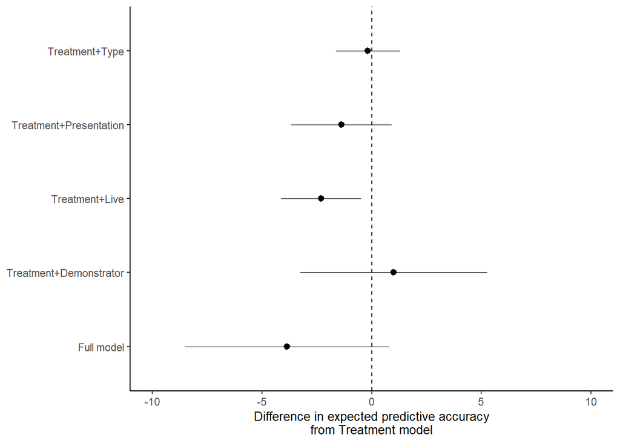

Plot condition parameter(s) with controls.

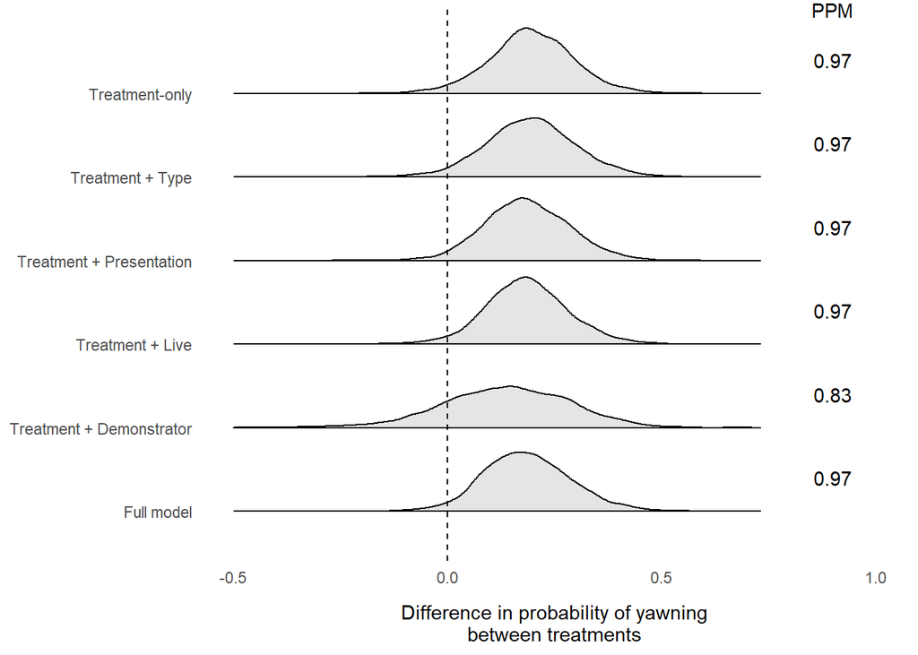

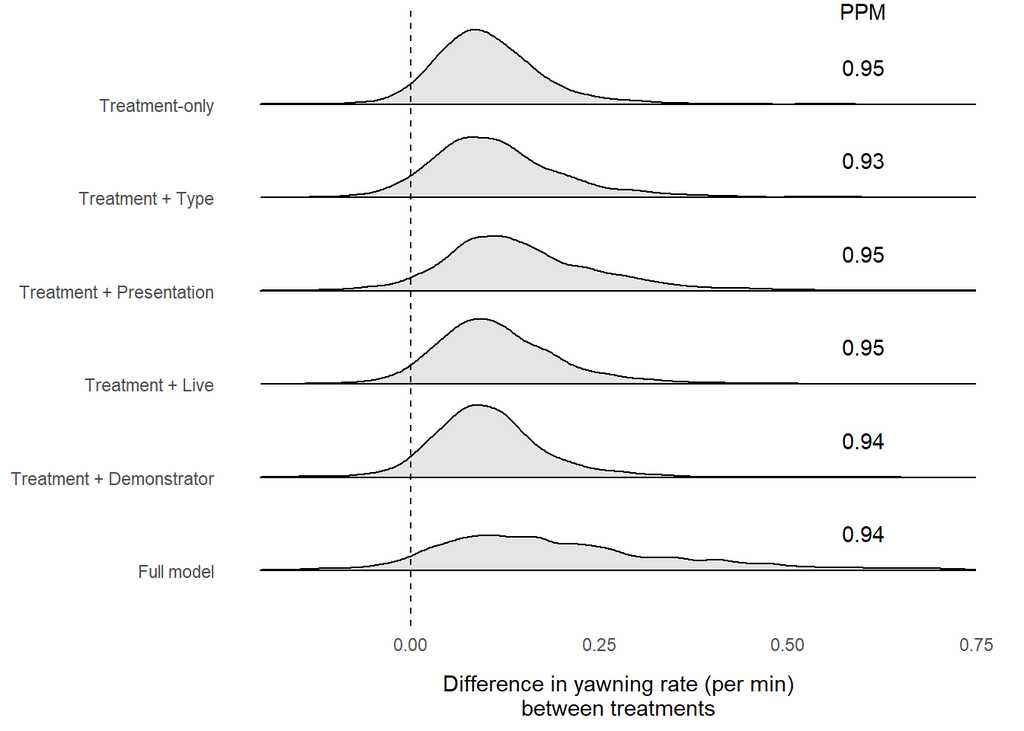

## 1.11. Gender-only model

```
##  Family: hurdle_poisson
##   Links: mu = log; hu = logit
## Formula: numberYawns ~ 0 + intercept + male + offset(log(secs)) + (0 + intercept + male | study) + (0 + intercept | study:ID)
##          hu ~ 0 + intercept + male + (0 + intercept + male | study) + (0 + intercept | study:ID)
##    Data: d (Number of observations: 686)
## Samples: 4 chains, each with iter = 2000; warmup = 1000; thin = 1;
##          total post-warmup samples = 4000
##
## Group-Level Effects:
## ~study (Number of levels: 6)
##                           Estimate Est.Error l-95% CI u-95% CI Rhat Bulk_ESS Tail_ESS
## sd(intercept)                 0.48      0.35     0.04     1.38 1.01     1047     1165
## sd(male)                      0.56      0.45     0.03     1.68 1.00      894      902
## sd(hu_intercept)              0.91      0.30     0.49     1.63 1.00     1459     1883
## sd(hu_male)                   0.28      0.22     0.01     0.80 1.00     1831     1528
## cor(intercept,male)          -0.03      0.55    -0.92     0.92 1.00     1703     2100
## cor(hu_intercept,hu_male)    -0.23      0.52    -0.96     0.83 1.00     2947     2756
##
## ~study:ID (Number of levels: 197)
##                  Estimate Est.Error l-95% CI u-95% CI Rhat Bulk_ESS Tail_ESS
## sd(intercept)        0.53      0.13     0.28     0.79 1.00      937     1087
## sd(hu_intercept)     0.75      0.23     0.24     1.16 1.01      580      466
##
## Population-Level Effects:
##              Estimate Est.Error l-95% CI u-95% CI Rhat Bulk_ESS Tail_ESS
## intercept       -5.76      0.29    -6.30    -5.18 1.00     1159     1470
## male            -0.24      0.32    -0.90     0.38 1.00     2111     2177
## hu_intercept     0.90      0.39     0.11     1.65 1.00     1101     1641
## hu_male         -0.16      0.26    -0.68     0.35 1.00     2341     2192
##
## Samples were drawn using sampling(NUTS). For each parameter, Eff.Sample
## is a crude measure of effective sample size, and Rhat is the potential
## scale reduction factor on split chains (at convergence, Rhat = 1).
```

Priors.

| prior | class | coef | group | resp | dpar | nlpar | bound |
| --- | --- | --- | --- | --- | --- | --- | --- |
|  | b |  |  |  |  |  |  |
| student_t(3, -2, 10) | b | intercept |  |  |  |  |  |
| normal(0, 1) | b | male |  |  |  |  |  |
|  | b |  |  |  | hu |  |  |
| logistic(0, 1) | b | intercept |  |  | hu |  |  |
| normal(0, 1) | b | male |  |  | hu |  |  |
| lkj_corr_cholesky(1) | L |  |  |  |  |  |  |
|  | L |  | study |  |  |  |  |
| student_t(3, 0, 10) | sd |  |  |  |  |  |  |
| student_t(3, 0, 0.5) | sd |  |  |  | hu |  |  |

[output cut: 10 more lines]

## 1.12. Condition + Gender model

```
##  Family: hurdle_poisson
##   Links: mu = log; hu = logit
## Formula: numberYawns ~ 0 + intercept + condition + male + offset(log(secs)) + (0 + intercept + condition + male | study) + (0 + intercept + condition | study:ID)
##          hu ~ 0 + intercept + condition + male + (0 + intercept + condition + male | study) + (0 + intercept + condition | study:ID)
##    Data: d (Number of observations: 686)
## Samples: 4 chains, each with iter = 2000; warmup = 1000; thin = 1;
##          total post-warmup samples = 4000
##
## Group-Level Effects:
## ~study (Number of levels: 6)
##                                Estimate Est.Error l-95% CI u-95% CI Rhat Bulk_ESS Tail_ESS
## sd(intercept)                      0.55      0.52     0.02     1.84 1.00     1476     1980
## sd(condition)                      0.92      0.65     0.17     2.56 1.00     1202     1695
## sd(male)                           0.50      0.42     0.02     1.56 1.00     1692     2004
## sd(hu_intercept)                   1.23      0.43     0.63     2.26 1.00     2233     2671
## sd(hu_condition)                   1.19      0.47     0.43     2.29 1.00     1736     1858
## sd(hu_male)                        0.30      0.24     0.01     0.86 1.00     2246     2023
## cor(intercept,condition)          -0.36      0.48    -0.97     0.75 1.00     1428     2117
## cor(intercept,male)               -0.17      0.50    -0.94     0.82 1.00     3277     2844
## cor(condition,male)                0.08      0.47    -0.80     0.89 1.00     3890     3334
## cor(hu_intercept,hu_condition)    -0.35      0.31    -0.82     0.33 1.00     2533     2376
## cor(hu_intercept,hu_male)         -0.24      0.45    -0.92     0.75 1.00     4613     2804
## cor(hu_condition,hu_male)          0.16      0.48    -0.81     0.92 1.00     4442     3474
##
## ~study:ID (Number of levels: 197)
##                                Estimate Est.Error l-95% CI u-95% CI Rhat Bulk_ESS Tail_ESS
## sd(intercept)                      0.57      0.18     0.23     0.97 1.00     1372     1592
## sd(condition)                      0.27      0.20     0.01     0.74 1.00     1149     1908
## sd(hu_intercept)                   0.98      0.24     0.52     1.47 1.00     1283     1829
## sd(hu_condition)                   0.29      0.23     0.01     0.87 1.00     1351     1900
## cor(intercept,condition)          -0.37      0.52    -0.98     0.85 1.00     2567     2459
## cor(hu_intercept,hu_condition)     0.06      0.57    -0.93     0.95 1.00     3535     2804
##
## Population-Level Effects:
##              Estimate Est.Error l-95% CI u-95% CI Rhat Bulk_ESS Tail_ESS
## intercept       -6.34      0.42    -7.28    -5.59 1.00     1651     1900
## condition        0.67      0.46    -0.19     1.63 1.00     2524     2335
## male            -0.24      0.30    -0.85     0.36 1.00     2924     2717
## hu_intercept     1.53      0.55     0.37     2.59 1.00     1326     1985
## hu_condition    -1.01      0.49    -1.95     0.05 1.00     2297     2706
## hu_male         -0.17      0.29    -0.75     0.37 1.00     4255     3136
##
## Samples were drawn using sampling(NUTS). For each parameter, Eff.Sample
## is a crude measure of effective sample size, and Rhat is the potential
## scale reduction factor on split chains (at convergence, Rhat = 1).
```

Priors.

| prior | class | coef | group | resp | dpar | nlpar | bound |
| --- | --- | --- | --- | --- | --- | --- | --- |
|  | b |  |  |  |  |  |  |
| normal(0, 1) | b | condition |  |  |  |  |  |
| student_t(3, -2, 10) | b | intercept |  |  |  |  |  |
| normal(0, 1) | b | male |  |  |  |  |  |
|  | b |  |  |  | hu |  |  |
| normal(0, 1) | b | condition |  |  | hu |  |  |
| logistic(0, 1) | b | intercept |  |  | hu |  |  |
| normal(0, 1) | b | male |  |  | hu |  |  |
| lkj_corr_cholesky(1) | L |  |  |  |  |  |  |
|  | L |  | study |  |  |  |  |

[output cut: 17 more lines]

Get yawning probability difference between conditions, controlling for gender.

```r
post <- posterior_samples(m5.12)

# yawning probability
cond1 <- 1 - inv_logit_scaled(post$b_hu_intercept)
median(cond1) %>% round(2)
```

```
## [1] 0.18
```

```r
cond2 <- 1 - inv_logit_scaled(post$b_hu_intercept + post$b_hu_condition)
median(cond2) %>% round(2)
```

```
## [1] 0.37
```

```r
diff <- cond2 - cond1

# proportion of prob mass above zero
(sum(diff > 0) / length(diff)) %>% round(2)
```

```
## [1] 0.97
```

Get yawning rate difference between conditions, controlling for gender.

```r
# yawning rates (per minute)
cond1 <- exp(post$b_intercept) * 60
median(cond1) %>% round(2)
```

```
## [1] 0.11
```

```r
cond2 <- exp(post$b_intercept + post$b_condition) * 60
median(cond2) %>% round(2)
```

```
## [1] 0.21
```

```r
diff <- cond2 - cond1

# proportion of prob mass above zero
(sum(diff > 0) / length(diff)) %>% round(2)
```

```
## [1] 0.95
```

## 1.13. Condition*Gender model

```
##  Family: hurdle_poisson
##   Links: mu = log; hu = logit
## Formula: numberYawns ~ 0 + intercept + condition * male + offset(log(secs)) + (0 + intercept + condition * male | study) + (0 + intercept + condition | study:ID)
##          hu ~ 0 + intercept + condition * male + (0 + intercept + condition * male | study) + (0 + intercept + condition | study:ID)
##    Data: d (Number of observations: 686)
## Samples: 4 chains, each with iter = 2000; warmup = 1000; thin = 1;
##          total post-warmup samples = 4000
##
## Group-Level Effects:
## ~study (Number of levels: 6)
##                                     Estimate Est.Error l-95% CI u-95% CI Rhat Bulk_ESS Tail_ESS
## sd(intercept)                           0.51      0.51     0.02     1.84 1.01     1011     1626
## sd(condition)                           0.86      0.62     0.06     2.45 1.00      627      588
## sd(male)                                0.55      0.49     0.02     1.83 1.00     1237     1645
## sd(condition:male)                      0.50      0.50     0.02     1.73 1.01     1208     1211
## sd(hu_intercept)                        1.19      0.40     0.63     2.18 1.00     1720     2583
## sd(hu_condition)                        1.01      0.49     0.19     2.14 1.00     1148      951
## sd(hu_male)                             0.30      0.24     0.01     0.88 1.00     2077     1788
## sd(hu_condition:male)                   0.46      0.35     0.02     1.28 1.00     1414     1509
## cor(intercept,condition)               -0.26      0.44    -0.92     0.68 1.00     1181     1718
## cor(intercept,male)                    -0.11      0.44    -0.85     0.74 1.00     3114     2696
## cor(condition,male)                     0.03      0.43    -0.76     0.82 1.00     3209     3005
## cor(intercept,condition:male)          -0.01      0.45    -0.81     0.83 1.00     3115     2857
## cor(condition,condition:male)           0.02      0.45    -0.82     0.82 1.00     3603     2524
## cor(male,condition:male)               -0.09      0.46    -0.86     0.79 1.00     2481     2967
## cor(hu_intercept,hu_condition)         -0.28      0.31    -0.80     0.40 1.00     1733     2069
## cor(hu_intercept,hu_male)              -0.15      0.43    -0.86     0.72 1.00     3667     2979
## cor(hu_condition,hu_male)               0.08      0.44    -0.78     0.83 1.00     3744     2776
## cor(hu_intercept,hu_condition:male)    -0.20      0.42    -0.86     0.68 1.00     3179     2689
## cor(hu_condition,hu_condition:male)     0.23      0.42    -0.66     0.89 1.00     3186     2811
## cor(hu_male,hu_condition:male)         -0.03      0.45    -0.82     0.80 1.00     2618     3178
##
## ~study:ID (Number of levels: 197)
##                                Estimate Est.Error l-95% CI u-95% CI Rhat Bulk_ESS Tail_ESS
## sd(intercept)                      0.59      0.18     0.27     0.98 1.00     1300     1645
## sd(condition)                      0.28      0.21     0.01     0.77 1.00      753     1194
## sd(hu_intercept)                   0.97      0.24     0.50     1.45 1.00     1102     1469
## sd(hu_condition)                   0.30      0.23     0.01     0.88 1.00      830     1028
## cor(intercept,condition)          -0.39      0.53    -0.98     0.86 1.00     1480     2243
## cor(hu_intercept,hu_condition)     0.08      0.56    -0.93     0.96 1.00     1839     2060
##
## Population-Level Effects:
##                   Estimate Est.Error l-95% CI u-95% CI Rhat Bulk_ESS Tail_ESS
## intercept            -6.27      0.43    -7.25    -5.53 1.00     1078     1393
## condition             0.57      0.46    -0.31     1.51 1.00     1462     2075
## male                 -0.37      0.40    -1.20     0.40 1.00     2223     2597
## condition:male        0.17      0.42    -0.63     0.99 1.00     1960     2309
## hu_intercept          1.54      0.52     0.46     2.53 1.00     1211     1738
## hu_condition         -1.03      0.47    -1.93    -0.06 1.00     1664     1542
## hu_male              -0.18      0.35    -0.90     0.51 1.00     2544     3014
## hu_condition:male     0.01      0.43    -0.84     0.88 1.00     2860     2762
##
## Samples were drawn using sampling(NUTS). For each parameter, Eff.Sample
## is a crude measure of effective sample size, and Rhat is the potential
## scale reduction factor on split chains (at convergence, Rhat = 1).
```

Priors.

| prior | class | coef | group | resp | dpar | nlpar | bound |
| --- | --- | --- | --- | --- | --- | --- | --- |
|  | b |  |  |  |  |  |  |
| normal(0, 1) | b | condition |  |  |  |  |  |
| normal(0, 1) | b | condition:male |  |  |  |  |  |
| student_t(3, -2, 10) | b | intercept |  |  |  |  |  |
| normal(0, 1) | b | male |  |  |  |  |  |
|  | b |  |  |  | hu |  |  |
| normal(0, 1) | b | condition |  |  | hu |  |  |
| normal(0, 1) | b | condition:male |  |  | hu |  |  |
| logistic(0, 1) | b | intercept |  |  | hu |  |  |
| normal(0, 1) | b | male |  |  | hu |  |  |

[output cut: 21 more lines]

Calculate yawning probabilities.

```r
post <- posterior_samples(m5.13)

# yawning rates (per minute)
cond1f <- 1 - inv_logit_scaled(post$b_hu_intercept)
cond2f <- 1 - inv_logit_scaled(post$b_hu_intercept + post$b_hu_condition)
cond1m <- 1 - inv_logit_scaled(post$b_hu_intercept + post$b_hu_male)
cond2m <- 1 - inv_logit_scaled(post$b_hu_intercept + post$b_hu_condition +
                    post$b_hu_male + post$`b_hu_condition:male`)

median(cond1f) %>% round(2)
```

```
## [1] 0.18
```

```r
median(cond2f) %>% round(2)
```

```
## [1] 0.38
```

```r
median(cond1m) %>% round(2)
```

```
## [1] 0.2
```

```r
median(cond2m) %>% round(2)
```

```
## [1] 0.42
```

```r
diff1 <- cond2m - cond1f
diff2 <- cond2m - cond2f
diff3 <- cond2m - cond1m
diff4 <- cond1m - cond1f
diff5 <- cond1m - cond2f
diff6 <- cond2f - cond1f

(sum(diff1 > 0) / length(diff1)) %>% round(2)
```

```
## [1] 0.98
```

```r
(sum(diff2 > 0) / length(diff2)) %>% round(2)
```

```
## [1] 0.67
```

```r
(sum(diff3 > 0) / length(diff3)) %>% round(2)
```

```
## [1] 0.96
```

```r
(sum(diff4 > 0) / length(diff4)) %>% round(2)
```

```
## [1] 0.71
```

```r
(sum(diff5 > 0) / length(diff5)) %>% round(2)
```

```
## [1] 0.05
```

```r
(sum(diff6 > 0) / length(diff6)) %>% round(2)
```

```
## [1] 0.98
```

Does the effect of condition differ between males and females? Interaction effect.

```r
(sum(diff3 - diff6 > 0) / length(diff3)) %>% round(2)
```

```
## [1] 0.55
```

Calculate yawning rates.

```r
# yawning rates (per minute)
cond1f <- exp(post$b_intercept) * 60
cond2f <- exp(post$b_intercept + post$b_condition) * 60
cond1m <- exp(post$b_intercept + post$b_male) * 60
cond2m <- exp(post$b_intercept + post$b_condition +
                    post$b_male + post$`b_condition:male`) * 60

median(cond1f) %>% round(2)
```

```
## [1] 0.12
```

```r
median(cond2f) %>% round(2)
```

```
## [1] 0.21
```

```r
median(cond1m) %>% round(2)
```

```
## [1] 0.08
```

```r
median(cond2m) %>% round(2)
```

```
## [1] 0.17
```

Are there any differences in yawning rate? Get proportions of prob mass above zero for each contrast.

```r
diff1 <- cond2m - cond1f
diff2 <- cond2m - cond2f
diff3 <- cond2m - cond1m
diff4 <- cond1m - cond1f
diff5 <- cond1m - cond2f
diff6 <- cond2f - cond1f

(sum(diff1 > 0) / length(diff1)) %>% round(2)
```

```
## [1] 0.75
```

```r
(sum(diff2 > 0) / length(diff2)) %>% round(2)
```

```
## [1] 0.28
```

```r
(sum(diff3 > 0) / length(diff3)) %>% round(2)
```

```
## [1] 0.92
```

```r
(sum(diff4 > 0) / length(diff4)) %>% round(2)
```

```
## [1] 0.17
```

```r
(sum(diff5 > 0) / length(diff5)) %>% round(2)
```

```
## [1] 0.04
```

```r
(sum(diff6 > 0) / length(diff6)) %>% round(2)
```

```
## [1] 0.9
```

Does the effect of condition differ between males and females? Interaction effect.

```r
(sum(diff3 - diff6 > 0) / length(diff3)) %>% round(2)
```

```
## [1] 0.5
```

Visualise.

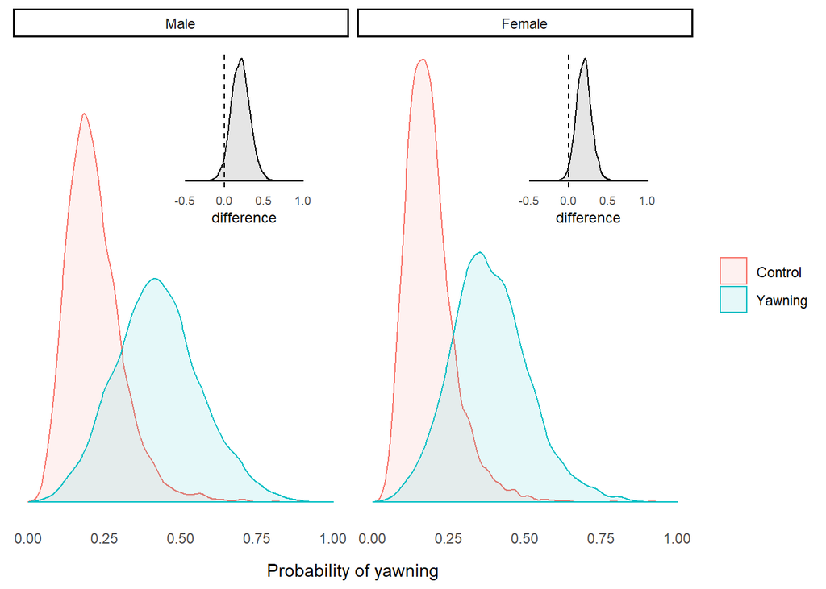

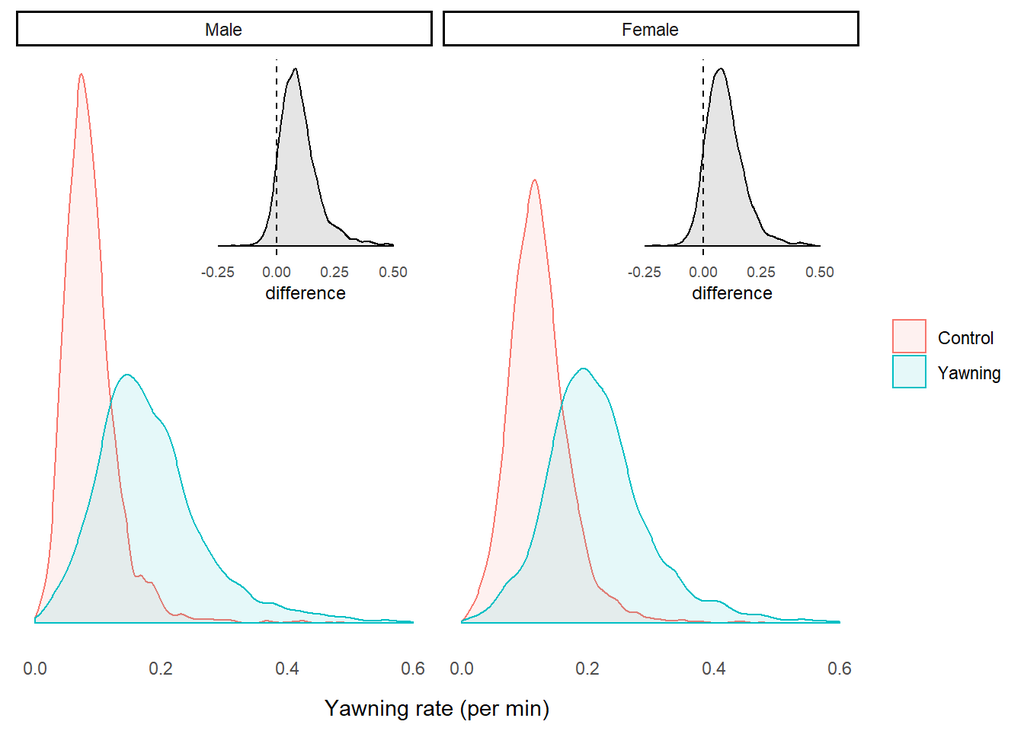

Let’s compare all the condition/gender models.

```r
loo_compare(m5.1, m5.2, m5.11, m5.12, m5.13)
```

[output not shown]

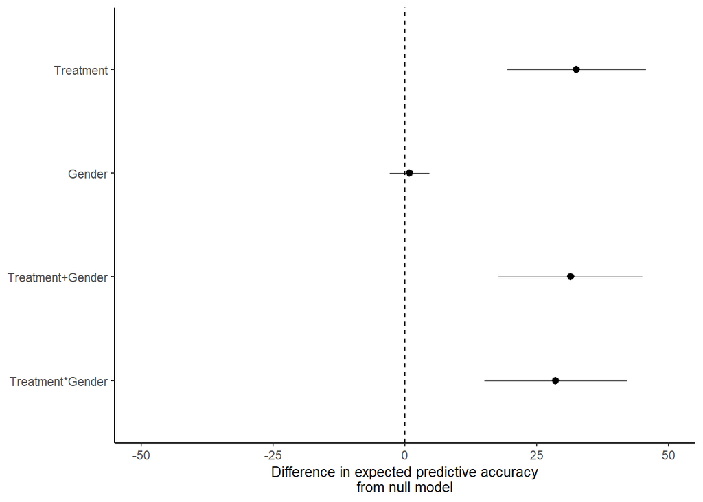

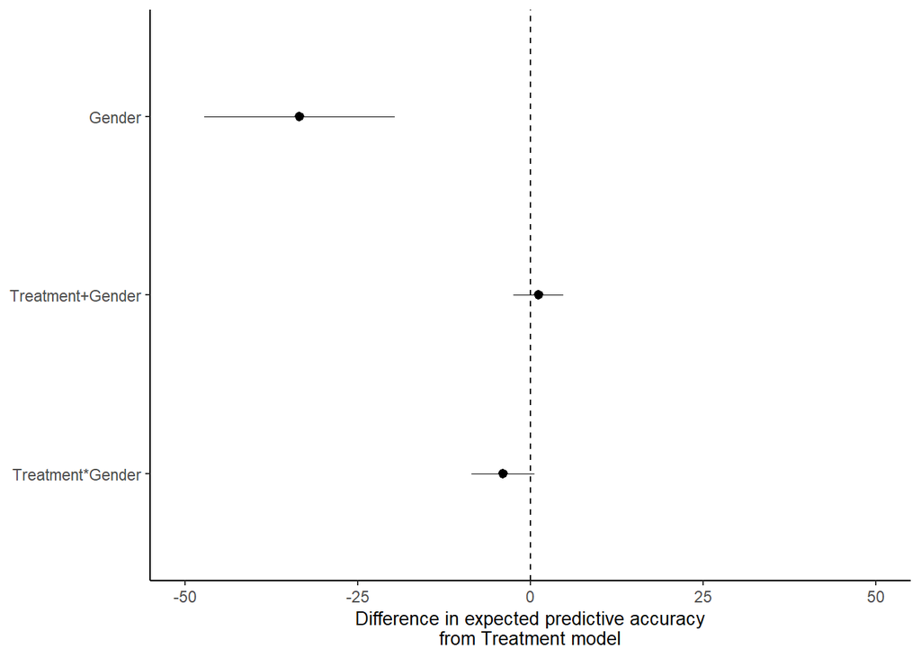